# Statistical Significance and Score Cards

Andrew Singleton

18/02/2022

```r
library(harp)
library(here)
library(dplyr)
library(patchwork)
library(tidyr)
library(forcats)
```

When we compare verification scores for different forecast models, it can be important to understand whether the differences between the scores are statistically significant. In harp this is done by bootstrapping.

## Bootstrapping

Bootstrapping is a process by which statistics are calculated from samples of different draws from the same data - we call these replicates. The statistics are calculated for each replicate and the variability between the replicates tells us something about how sure we can be about the statistic.

For forecast verification, this means calculating the scores for many replicates. We can then estimate the confidence intervals for the scores and / or the confidence of the differences between scores for different forecast models.

Here we will once again make a comparison between REF and IFSENS for 2m temperature. As usual we will read the forecasts in, select the common cases and join them together. Since it’s temperature we will also convert K to degrees C.

```r
t2m <- read_point_forecast(
  dttm       = seq_dttm(2018030800, 2018033100, "1d"),
  fcst_model = c("REF", "IFSENS"),
  fcst_type  = "eps",
  parameter  = "T2m",
  file_path  = here("data/FCTABLE"),
  file_template = list(
    REF    = "fctable",
    IFSENS = "fctable_eps"
  )
) %>%
  scale_param(-273.15, "degC") %>%
  common_cases() %>%
  join_to_fcst(
    read_point_obs(
      unique_valid_dttm(.),
      parameter = "T2m",
      stations  = unique_stations(.),
      obs_path  = here("data/OBSTABLE")
    ) %>%
      scale_param(-273.15, "degC", col = T2m)
  )
```

We’re going to do an extra check on the observations using `check_obs_against_fcst()`, which only allows observations that are within a certain number of standard deviations of the forecast.

```r
t2m <- check_obs_against_fcst(t2m, T2m, num_sd_allowed = 6)
```

And now we’ll just do a verification as normal (switching off deterministic verification for members for speed).

```r
verif <- ens_verify(t2m, T2m, verify_members = FALSE)
```

```
## ::Computing verification for fcst_model `REF`::
```

```
## Spread; Skill for lead_time
```

```
## ✔
```

```
## Hexbin for lead_time✔
```

```
## Rank histogram for lead_time✔
```

```
## CRPS for lead_time✔
```

```
## ::Computing verification for fcst_model `IFSENS`::
```

```
## Spread; Skill for lead_time✔
## Hexbin for lead_time✔
## Rank histogram for lead_time✔
## CRPS for lead_time✔
```

We’re going to concentrate on spread-skill, bias of the ensemble mean and CRPS for this analysis, and we’ll use patchwork to arrange the plots.

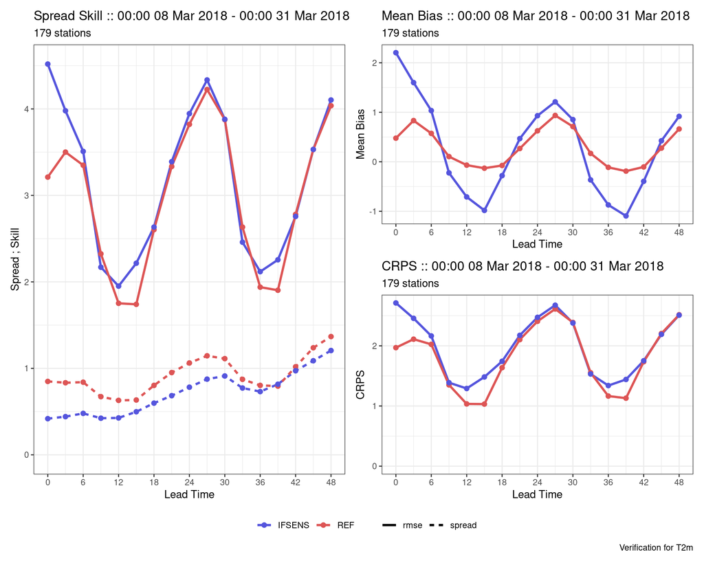

```r
my_cols <- data.frame(
  mname = names(t2m),
  colour = c("#DD5555", "#5555DD")
)
plot_point_verif(
  verif, spread_skill, plot_num_cases = FALSE, plot_caption = "", colour_table = my_cols) +
  plot_point_verif(verif, mean_bias, plot_num_cases = FALSE, plot_caption = "", colour_table = my_cols) /
  plot_point_verif(verif, crps, plot_num_cases = FALSE, colour_table = my_cols) +
  plot_layout(guides = "collect") &
  theme(legend.position = "bottom")
```

If we want to bootstrap the verification we use `bootstrap_verify()`, which takes the forecast data, the verification function, the parameter, the number of bootstrap replicates and other arguments to the verification function as its arguments. You can also do the bootstrapping in parallel if you have access to more than one core by setting parallel = TRUE.

```r
bootstrap_verify(
  t2m,
  ens_verify,
  T2m,
  n = 10,
  show_progress = TRUE
)
```

```
## ::ens_summary_scores:: # A tibble: 272 × 17
##    fcst_model ref_model lead_time score          ref_score_mean ref_score_median
##    <chr>      <chr>         <int> <chr>                   <dbl>            <dbl>
##  1 IFSENS     REF               0 crps                    1.97             1.97
##  2 IFSENS     REF               0 crps_potential          1.43             1.43
##  3 IFSENS     REF               0 crps_reliabil…          0.539            0.540
##  4 IFSENS     REF               0 mean_bias               0.501            0.507
##  5 IFSENS     REF               0 rmse                    3.22             3.21
##  6 IFSENS     REF               0 spread                  0.849            0.846
##  7 IFSENS     REF               0 spread_skill_…          0.264            0.262
##  8 IFSENS     REF               0 stde                    3.18             3.17
##  9 IFSENS     REF               3 crps                    2.11             2.11
## 10 IFSENS     REF               3 crps_potential          1.47             1.47
## # ℹ 262 more rows
## # ℹ 11 more variables: ref_score_upper <dbl>, ref_score_lower <dbl>,
## #   fcst_score_mean <dbl>, fcst_score_median <dbl>, fcst_score_upper <dbl>,
## #   fcst_score_lower <dbl>, difference_mean <dbl>, difference_median <dbl>,
## #   difference_upper <dbl>, difference_lower <dbl>, percent_better <dbl>
##
## --harp verification for T2m--
##  # for forecasts from 00:00 UTC 08 Mar 2018 to 00:00 UTC 31 Mar 2018
##  # using 179 observation stations
##  # for verification groups:
##     -> lead_time
```

```
## ℹ use `attributes()` to see detailed metadata
```

That’s pretty slow, so we can switch parallel to TRUE.

```r
bs_verif <- bootstrap_verify(
  t2m,
  ens_verify,
  T2m,
  n = 100,
  parallel = TRUE,
  num_cores = 50
)
```

```
## Bootstrapping on 8 cores.
```

```r
bs_verif
```

```
## ::ens_summary_scores:: # A tibble: 272 × 17
##    fcst_model ref_model lead_time score          ref_score_mean ref_score_median
##    <chr>      <chr>         <int> <chr>                   <dbl>            <dbl>
##  1 IFSENS     REF               0 crps                    1.97             1.97
##  2 IFSENS     REF               0 crps_potential          1.43             1.43
##  3 IFSENS     REF               0 crps_reliabil…          0.538            0.540
##  4 IFSENS     REF               0 mean_bias               0.483            0.480
##  5 IFSENS     REF               0 rmse                    3.22             3.21
##  6 IFSENS     REF               0 spread                  0.849            0.849
##  7 IFSENS     REF               0 spread_skill_…          0.264            0.265
##  8 IFSENS     REF               0 stde                    3.18             3.18
##  9 IFSENS     REF               3 crps                    2.11             2.11
## 10 IFSENS     REF               3 crps_potential          1.47             1.47
## # ℹ 262 more rows
## # ℹ 11 more variables: ref_score_upper <dbl>, ref_score_lower <dbl>,
## #   fcst_score_mean <dbl>, fcst_score_median <dbl>, fcst_score_upper <dbl>,
## #   fcst_score_lower <dbl>, difference_mean <dbl>, difference_median <dbl>,
## #   difference_upper <dbl>, difference_lower <dbl>, percent_better <dbl>
##
## --harp verification for T2m--
##  # for forecasts from 00:00 UTC 08 Mar 2018 to 00:00 UTC 31 Mar 2018
##  # using 179 observation stations
##  # for verification groups:
##     -> lead_time
```

```
## ℹ use `attributes()` to see detailed metadata
```

It’s worth noting what each of the columns in the output is:

- **fcst_model** - The model whose score we are interested in
- **ref_model** - When comparing models, this model is used as the reference
- **leadtime** - The forecast lead time
- **score** - the verification score
- **ref_score_<stat>** - these are the bootstrap statistics for *ref_model* - the mean, the median, and the upper and lower bounds of the confidence interval that are set in bootstrap_verify() (the default is 95%)
- **fcst_score_<stat>** - the same as *ref_score_<stat>* except for *fcst_model*
- **difference_<stat>** - The mean, median and upper and lower confidence bounds for the score for *fcst_model* - *ref_model*
- **percent_better** - The percentage of *fcst_model* that have a better score than *ref_model*. This can be thought of as the confidence of *fcst_model* - *ref_model*

harpVis doesn’t yet have a function that is capable of dealing with this type of data, but a function to plot scores with confidence intervals might look something like this:

```r
plot_func <- function(x, plot_score, conf = c("ribbon", "errorbar"), alpha = 0.5) {

  conf <- match.arg(conf)

  p <- ggplot(
    filter(x$ens_summary_scores, score %in% plot_score),
    aes(
      x        = lead_time,
      y        = fcst_score_mean,
      ymin     = fcst_score_lower,
      ymax     = fcst_score_upper,
      colour   = fcst_model,
      fill     = fcst_model,
      linetype = score
    )
  )

  if (conf == "errorbar") {
    p <- p + geom_errorbar()
  }

  if (conf == "ribbon") {
    p <- p + geom_ribbon(alpha = alpha, colour = NA) +
      scale_fill_manual(values = c(REF = "#DD5555", IFSENS = "#5555DD")) +
      guides(fill = "none")
  }

  p <- p + geom_line() +
    scale_x_continuous(breaks = seq(0, 48, 6)) +
    labs(
      x = "Lead Time [h]",
      y = paste(harpVis:::totitle(gsub("_", " ", plot_score)), collapse = "; "),
      colour = NULL,
      linetype = NULL,
      title = paste0(
        paste(harpVis:::totitle(gsub("_", " ", plot_score)), collapse = "; "),
        " : ",
        paste(
          format(as_dttm(range(attr(x, "dttm"))), "%H:%M %d %b %Y"),
          collapse = " - "
        )
      ),
      subtitle = paste(length(attr(x, "stations")), "Stations")
    ) +
    scale_colour_manual(values = c(REF = "#DD5555", IFSENS = "#5555DD"))

  if (length(plot_score) < 2) {
    p <- p +
      guides(linetype = "none")
  } else {
    p <- p +
      guides(linetype = guide_legend(NULL, override.aes = list(fill = NA)))
  }

  p + theme(legend.position = "bottom")
}
```

Then we can use the function to construct our plot, but now with added error bars!

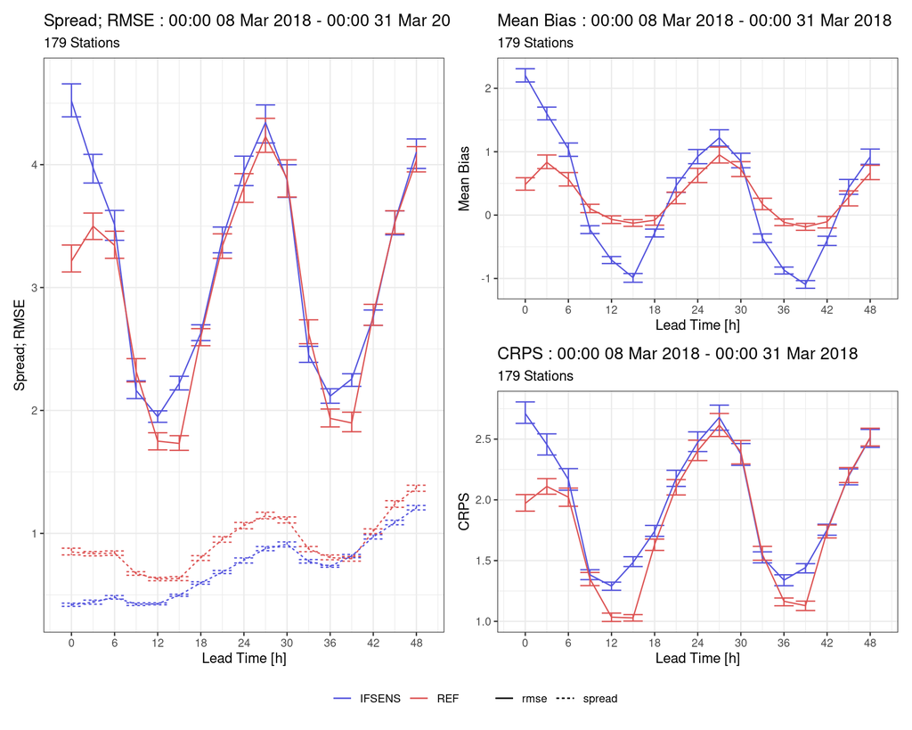

```r
plot_func(bs_verif, c("spread", "rmse"), "errorbar") +
  plot_func(bs_verif, c("mean_bias"), "errorbar") /
  plot_func(bs_verif, c("crps"), "errorbar") +
  plot_layout(guides = "collect") &
  theme_bw() &
  theme(legend.position = "bottom")
```

Error bars can sometimes clutter the plot, so a ribbon around the confidence interval can be better.

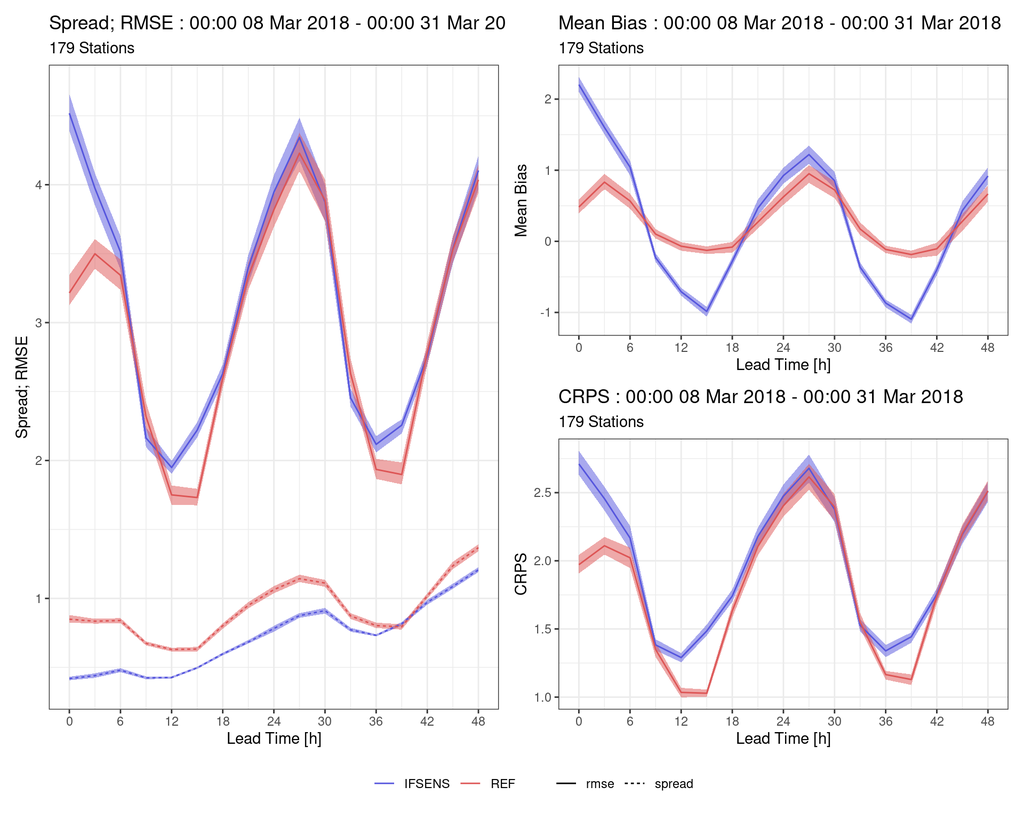

```r
plot_func(bs_verif, c("spread", "rmse"), "ribbon") +
  plot_func(bs_verif, c("mean_bias"), "ribbon") /
  plot_func(bs_verif, c("crps"), "ribbon") +
  plot_layout(guides = "collect") &
  theme_bw() &
  theme(legend.position = "bottom")
```

We can also make a function to plot the difference between two models and the confidence of that difference for a given interval.

```r
plot_diff_func <- function(
  x, plot_score, fcst_model, ref_model, significance = 0.95,
  conf = c("ribbon", "errorbar"), alpha = 0.5
) {

  conf <- match.arg(conf)

  sig_text <- c(
    paste0(
      fcst_model, " better than ", ref_model,
      " with ", significance * 100, "% confidence"
    ),
    paste0(
      fcst_model, " worse than ", ref_model,
      " with ", significance * 100, "% confidence"
    ),
    paste0(
      "No difference between ", fcst_model, " and ", ref_model,
      " with ", significance * 100, "% confidence"
    )
  )

  shapes <- c(24, 25, 1)
  names(shapes) <- sig_text

  colours <- c("#5555DD", "#DD5555", "#ACACAC")
  names(colours) <- sig_text

  plot_data <- filter(
    x$ens_summary_scores,
    score %in% plot_score,
    fcst_model == .env$fcst_model,
    ref_model == .env$ref_model
  ) %>%
    mutate(
      sig = case_when(
        percent_better >= significance       ~ sig_text[1],
        percent_better <= (1 - significance) ~ sig_text[2],
        TRUE                                 ~ sig_text[3]
      )
    )

    p <- ggplot(
    plot_data,
    aes(
      x        = lead_time,
      y        = difference_mean,
      ymin     = difference_lower,
      ymax     = difference_upper,
      linetype = score
    )
  ) +
    labs(
      x = "Lead Time [h]",
      y = paste(harpVis:::totitle(gsub("_", " ", plot_score)), collapse = "; "),
      colour = NULL,
      linetype = NULL,
      shape = NULL,
      title = paste0(
        paste(harpVis:::totitle(gsub("_", " ", plot_score)), collapse = "; "),
        " : ",
        paste(
          format(as_dttm(range(attr(x, "dttm"))), "%H:%M %d %b %Y"),
          collapse = " - "
        )
      ),
      subtitle = paste(
        fcst_model, "-", ref_model, "at",
        length(attr(x, "stations")), "Stations"
      )
    )

  if (length(plot_score) < 2) {
    p <- p +
      guides(linetype = "none")
  } else {
    p <- p +
      guides(linetype = guide_legend(NULL, override.aes = list(fill = NA)))
  }

  if (conf == "errorbar") {
    p <- p + geom_errorbar(colour = "#555555")
  }

  if (conf == "ribbon") {
    p <- p + geom_ribbon(alpha = alpha, fill = "#AAAAAA") + guides(fill = "none")
  }

  p +
    geom_line(colour = "#555555") +
    geom_point(aes(shape = sig, colour = sig, fill = sig)) +
    scale_colour_manual(values = colours) +
    scale_fill_manual(values = colours) +
    scale_shape_manual(values = shapes) +
    scale_x_continuous(breaks = seq(0, 48, 6)) +
    guides(
      colour = guide_legend(nrow = 3),
      fill = guide_legend(NULL, nrow = 3),
      shape = guide_legend(nrow = 3)
    ) +
    theme_bw() +
    theme(legend.position = "bottom")
}
```

And now we can do the same layout

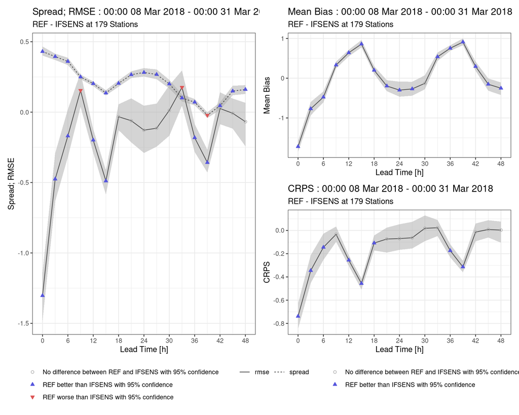

```r
plot_diff_func(bs_verif, c("spread", "rmse"), "REF", "IFSENS", 0.95, "ribbon") +
  plot_diff_func(bs_verif, "mean_bias", "REF", "IFSENS", 0.95, "ribbon") /
  plot_diff_func(bs_verif, "crps", "REF", "IFSENS", 0.95, "ribbon") +
  plot_layout(guides = "collect") &
  theme(legend.position = "bottom")
```

# Serial correlations

In bootstrapping a problem arises if the data are in some way serially correlated - whether that be in time or space. In order to get a representative statistic for each bootstrap replicate we need to ensure that those serial correlations are maintained for each replicate.

### Spatial autocorrelations

The computation and interpretation of spatial autocorrelations is quite complicated, so it won’t be covered here (but e.g. see [moran.test from the spdep package](https://www.rdocumentation.org/packages/spdep/versions/1.1-7/topics/moran.test)). However, we can ignore the impact of spatial autocorrelations altogether by making sure that every station is represented in each bootstrap replicate. This can be done by pooling the data so that a so called “block” bootstrap can be used whereby blocks of data are drawn with replacement from the dataset. To ensure that all stations are included in each bootstrap replicate we can pool the data by forecast date. This is done with the `pool_by` argument to `bootstrap_verify()` where unique values in the column named in `pool_by` are used to group the data together.

```r
bs_fcdate_block <- bootstrap_verify(
  t2m, ens_verify, T2m, 100, pool_by = "fcst_dttm", parallel = TRUE, num_cores = 50
)
```

```
## Bootstrapping on 8 cores.
```

We can now compare how the confidence interval for the differences compare - on the left is the basic bootstrap, and on the right with replicates drawing from pools of data from forecast dates.

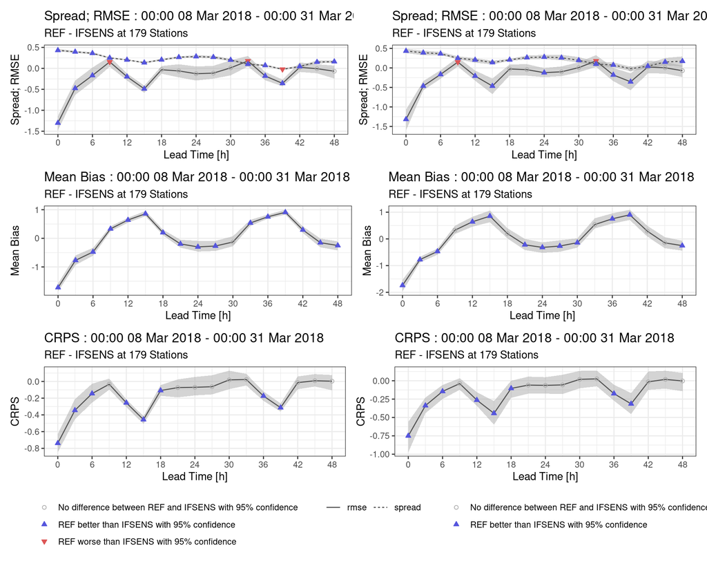

```r
(
  plot_diff_func(bs_verif, c("spread", "rmse"), "REF", "IFSENS") +
  plot_diff_func(bs_fcdate_block, c("spread", "rmse"), "REF", "IFSENS")
) /
(
  plot_diff_func(bs_verif, c("mean_bias"), "REF", "IFSENS") +
  plot_diff_func(bs_fcdate_block, c("mean_bias"), "REF", "IFSENS")
) /
(
  plot_diff_func(bs_verif, c("crps"), "REF", "IFSENS") +
  plot_diff_func(bs_fcdate_block, c("crps"), "REF", "IFSENS")
) +
  plot_layout(guides = "collect") &
  theme(legend.position = "bottom")
```

It is clear that the the differences become less confident with a widening of the error bars and a change in the significance of some of the differences, particularly for the bias.

### Temporal autocorrelations

Let’s look at how the errors are correlated in time. We can do this by grouping the verification by lead time and forecast date and then calculating the autocorrelations, using R’s `acf()` function, as a function of the forecast date for each lead time.

```r
verif_time <- ens_verify(
  t2m, T2m, groupings = c("lead_time", "fcst_dttm"), verify_members = FALSE,
  hexbin = FALSE, rank_hist = FALSE
)
```

`acf()` returns a list, but we just want to get the lag and the autocorrelation values from it so we make a function to extract those variables into a data frame.

```r
acf_to_df <- function(x) {
  ac <- acf(x, plot = FALSE)
  data.frame(lag = as.vector(ac$lag), autocorrelation = as.vector(ac$acf))
}
```

We can then use dplyr’s `summarise()` function to compute the autocorrelations for each lead time and forecast model. We need to make sure that the data are arranged in order of fcdate to have the correct lags.

```r
autocorr <- group_by(verif_time$ens_summary_scores, fcst_model, lead_time) %>%
  arrange(fcst_dttm) %>%
  summarise(ac = list(acf_to_df(mean_bias))) %>%
  unnest(ac)
```

And now we see how the forecast errors are correlated in time for each of the models.

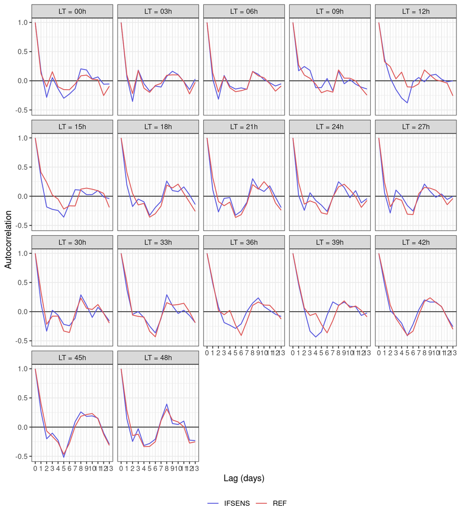

```r
ggplot(autocorr, aes(lag, autocorrelation, fill = fcst_model, colour = fcst_model)) +
  geom_abline(colour = "grey20", slope = 0, intercept = 0) +
  geom_line() +#position = "dodge") +
  facet_wrap(vars(
    paste0("LT = ", fct_inorder(formatC(lead_time, width = 2, flag = "0")), "h")
  )) +
  scale_colour_manual(NULL, values = c(REF = "#DD5555", IFSENS = "#5555DD")) +
  scale_x_continuous(breaks = seq(0, 20)) +
  theme_bw() +
  labs(x = "Lag (days)", y = "Autocorrelation", fill = NULL) +
  theme(legend.position = "bottom")
```

In general the errors are autocorrelated for 1 - 2 days, but in some cases it’s up to 4 days. We can use the information to create pools of consecutive days for the block bootstrap. For these data a pool size of 4 days (day 0 - day 3) seems like a good compromise. However, this could be different depending on the forecast parameter, time of year and model domain. Generating the pools is a two stage process - first we need to define the pools using `make_bootstrap_pools()`. We can then pass the output of this to the `pool_by` argument in `bootstrap_verify()`.

```r
bs_4day_pools <- make_bootstrap_pools(t2m, fcst_dttm, "4d")
bs_4day_pools
```

```
## # A tibble: 23 × 2
##    fcst_dttm            pool
##    <dttm>              <dbl>
##  1 2018-03-08 00:00:00     1
##  2 2018-03-09 00:00:00     1
##  3 2018-03-10 00:00:00     1
##  4 2018-03-11 00:00:00     1
##  5 2018-03-12 00:00:00     2
##  6 2018-03-13 00:00:00     2
##  7 2018-03-14 00:00:00     2
##  8 2018-03-15 00:00:00     2
##  9 2018-03-16 00:00:00     3
## 10 2018-03-17 00:00:00     3
## # ℹ 13 more rows
```

```r
bs_4day_block <- bootstrap_verify(
  t2m, ens_verify, T2m, 100, pool_by = bs_4day_pools, parallel = TRUE, num_cores = 50
)
```

```
## Bootstrapping on 8 cores.
```

Now we can compare the impact of including temporal autocorrelations in the bootstrapping procedure - the pooling by forecast date is on the left and by pools of 4 forecast days is on the right.

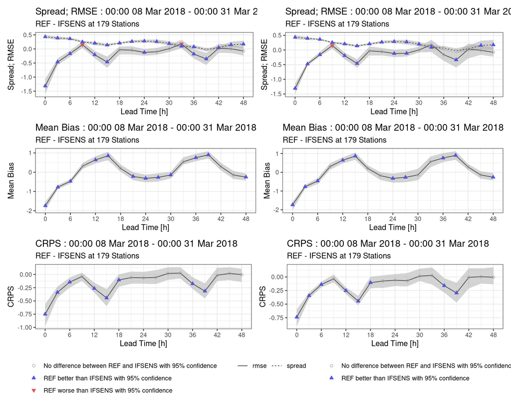

```r
(
  plot_diff_func(bs_fcdate_block, c("spread", "rmse"), "REF", "IFSENS") +
  plot_diff_func(bs_4day_block, c("spread", "rmse"), "REF", "IFSENS")
) /
(
  plot_diff_func(bs_fcdate_block, c("mean_bias"), "REF", "IFSENS") +
  plot_diff_func(bs_4day_block, c("mean_bias"), "REF", "IFSENS")
) /
(
  plot_diff_func(bs_fcdate_block, c("crps"), "REF", "IFSENS") +
  plot_diff_func(bs_4day_block, c("crps"), "REF", "IFSENS")
) +
  plot_layout(guides = "collect") &
  theme(legend.position = "bottom")
```

A final thing to consider is whether the pools of data should overlap so that all serial correlations in time are kept. We can do that by setting `overlap = TRUE` when making the pools.

```r
bs_4day_ol_pools <- make_bootstrap_pools(t2m, fcst_dttm, "4d", overlap = TRUE)
bs_4day_ol_block <- bootstrap_verify(
  t2m, ens_verify, T2m, 100, pool_by = bs_4day_ol_pools, parallel = TRUE, num_cores = 50
)
```

```
## Bootstrapping on 8 cores.
```

Again we can compare the difference - 4 day pools on the left, 4 day overlapping pools on the right.

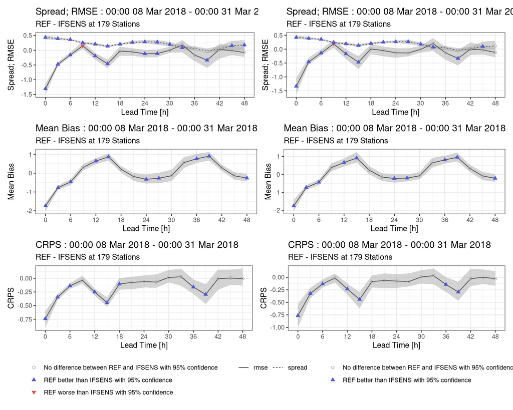

```r
(
  plot_diff_func(bs_4day_block, c("spread", "rmse"), "REF", "IFSENS") +
  plot_diff_func(bs_4day_ol_block, c("spread", "rmse"), "REF", "IFSENS")
) /
(
  plot_diff_func(bs_4day_block, c("mean_bias"), "REF", "IFSENS") +
  plot_diff_func(bs_4day_ol_block, c("mean_bias"), "REF", "IFSENS")
) /
(
  plot_diff_func(bs_4day_block, c("crps"), "REF", "IFSENS") +
  plot_diff_func(bs_4day_ol_block, c("crps"), "REF", "IFSENS")
) +
  plot_layout(guides = "collect") &
  theme(legend.position = "bottom")
```

Here there is no obvious difference, so maybe the pools do not need to overlap.

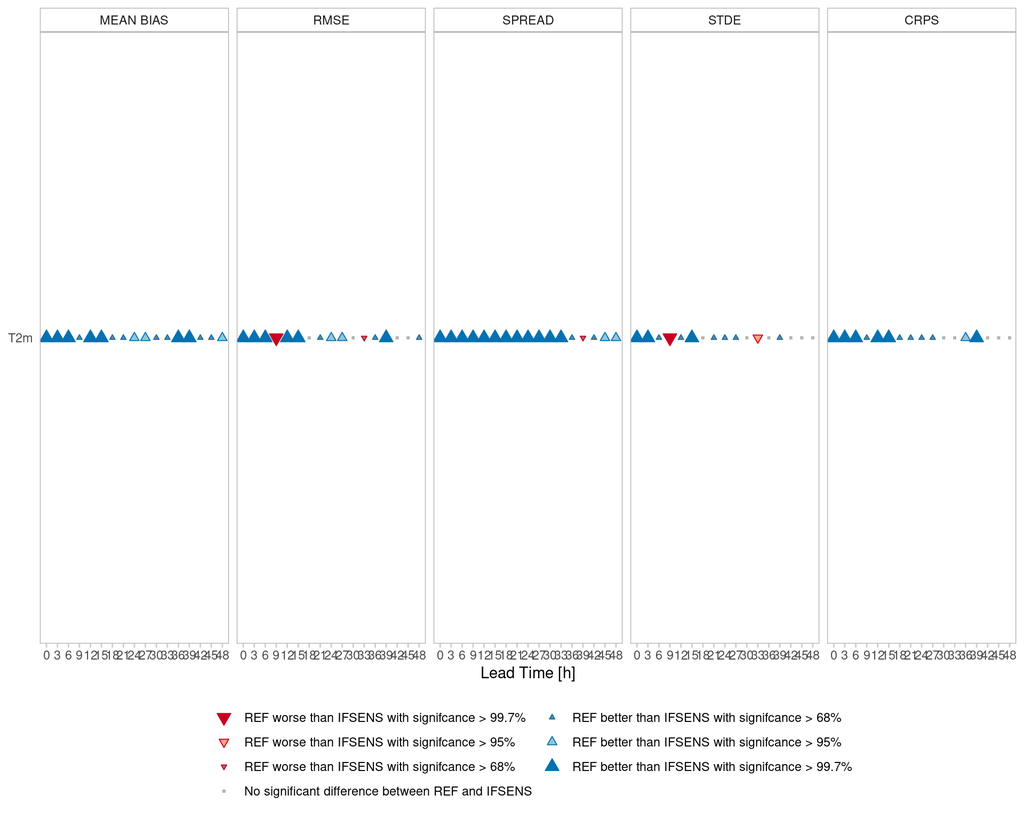

```r
plot_scorecard(
  bs_4day_block,
  fcst_model = "REF",
  ref_model  = "IFSENS",
  scores     = c(
    "mean_bias", "rmse", "spread", "stde", "crps"
  )
)
```